# SeqSurf AI

Paper-grounded transcriptomic reanalysis for healthcare AI

Author

Selah McKenney

Published

June 24, 2026

## 1 Goal

**SeqSurf AI is designed to make public transcriptomic reanalysis easier, more reproducible, and more comparable across studies.** The long-term goal is a standardized AI-assisted workflow where a user can enter a GEO accession, understand what has already been done with the dataset, decide whether reanalysis is worthwhile, reproduce or approximate prior findings, and then receive better next-analysis recommendations.

## 2 Healthcare AI Niche

Modern biomedical research produces enormous public sequencing and expression datasets. The problem is not only access. The harder problem is consistency: different groups reuse GEO datasets with different preprocessing choices, different phenotype definitions, different contrasts, and different levels of paper-grounded validation. That makes conclusions difficult to compare.

SeqSurf AI targets the gap between a literature summarizer and a full bioinformatics pipeline. A general AI assistant can summarize papers, and a workflow manager can run code, but neither one usually enforces a reproducible analysis contract that connects:

- the public dataset,
- the original paper and claims,
- the available expression or count data,
- the selected contrast,
- the reanalysis results,
- the reproducibility score,
- the known pitfalls,
- and the next scientifically useful analysis.

SeqSurf AI is intended to fill that niche: **an AI-guided reproducibility layer for public transcriptomic datasets.**

## 3 Problem, Gap, Solution

| Area | Summary |
| --- | --- |
| Problem | Everyone sequences, but public transcriptomic conclusions are hard to compare. |
| Gap | GEO datasets are reused inconsistently; AI tools can summarize papers but do not enforce reproducible analysis contracts. |
| Solution | SeqSurf AI standardizes dataset triage, paper-grounded reanalysis, claim validation, and adaptive learning. |
| Demo case | `GSE19804`, a public lung cancer expression dataset, is the main prepared demo dataset. |
| Evaluation | Show workflow completion, route classification, generated reanalysis score, paper-claim comparison, and standardized pitfall surfacing. |

## 4 What The App Does Today

SeqSurf AI currently behaves like a guided research assistant wrapped around a Shiny analysis app. The user starts with a GEO accession or an uploaded dataset. The app then decides what kind of analysis route is realistic.

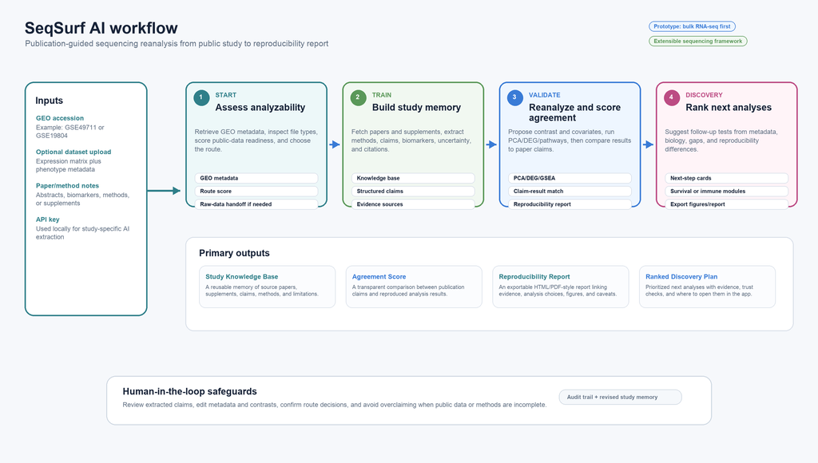

**Figure 1.** SeqSurf AI workflow. The app moves from dataset triage to study memory, reanalysis, paper agreement, scoring, and discovery.

### 4.1 1. Enter A GEO Accession

The user enters a GEO accession such as `GSE19804`. SeqSurf AI retrieves or loads study context and assesses whether the dataset can be analyzed in-app.

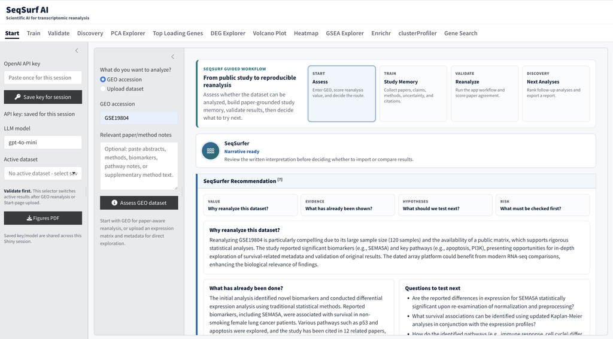

### 4.2 2. Classify The Route

Not every GEO dataset is equally ready for reanalysis. SeqSurf AI separates datasets into practical routes:

- **In-app processed-matrix reanalysis:** expression data and phenotype metadata are available enough to analyze directly.
- **Count-matrix import:** count-like files are present and can be converted into the app contract.
- **External raw/SRA workflow:** raw sequencing data likely requires an external pipeline before SeqSurf can analyze the expression matrix.
- **Not ready:** missing or ambiguous files, metadata, or phenotype definitions need user review.

This route classification matters because it prevents the app from pretending that every accession is immediately analyzable.

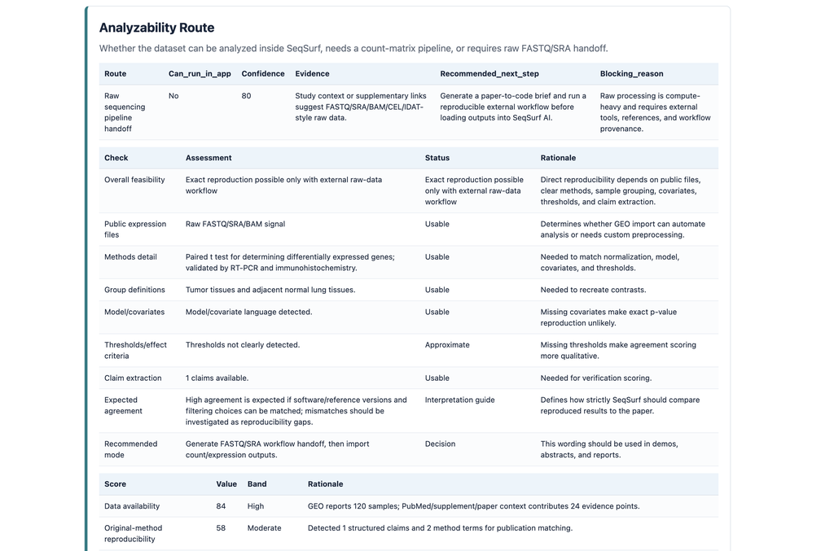

### 4.3 3. Build Paper-Grounded Study Memory

SeqSurf AI is not only analyzing numbers. It also builds a study memory: methods, claims, relevant paper excerpts, uncertainty, citation evidence, and notes that help determine what the reanalysis should test.

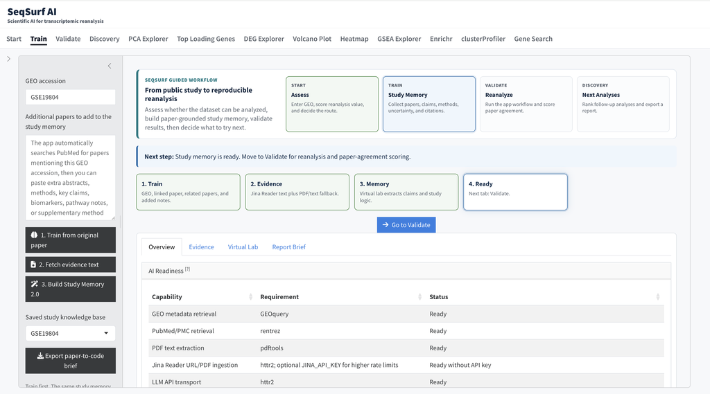

The intended training signal is structured:

| Input | Label | Output Target |
| --- | --- | --- |
| GEO metadata, route, paper claims, methods, result summaries | useful/not useful, reproduced/failed, best next analysis, pitfalls | ideal recommendation, score, warning, or signature plan |

### 4.4 4. Reanalyze And Validate Against The Paper

After the app has a dataset and a proposed design, it can run the standardized in-app analysis path. For a processed expression dataset, this includes PCA, DEG-style result exploration, volcano plots, heatmaps, pathway summaries, paper-claim comparison, and a reproducibility score.

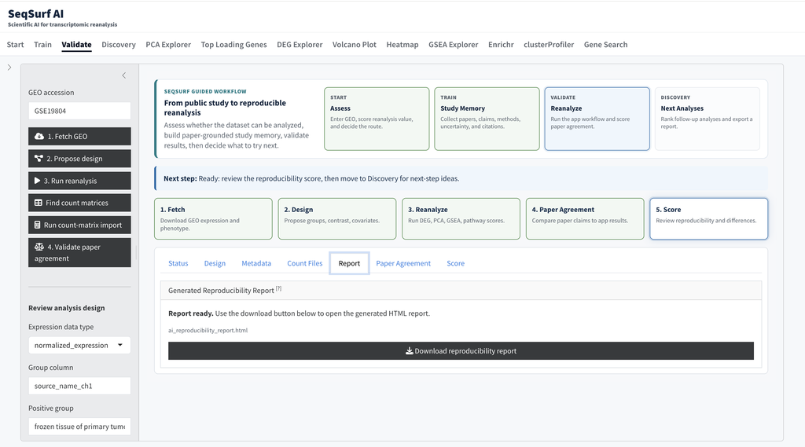

For the `GSE19804` demo, the app uses a prepared local processed-expression dataset at:

`SeqSurf_AI/data/geo_gse19804`

That means the live demo does **not** need to download FASTQ/SRA files or run alignment. Instead, it demonstrates the intended analysis contract on a cached GEO expression dataset so the presentation is fast and reliable.

### 4.5 5. Score Reproducibility And Surface Differences

The score step compares app results to extracted paper claims. The goal is not to declare the original paper right or wrong with a single number. The goal is to provide a structured reproducibility view:

- Which paper claims appear supported by the reanalysis?
- Which claims are different, incomplete, or not testable with the current app dataset?
- Which metadata or design choices could explain differences?
- Which findings are relevant enough to follow up?

### 4.6 6. Recommend Discovery Analyses

After validation, SeqSurf AI can recommend next analyses. This is where the app becomes more than a reproduction tool. It can suggest modern reanalysis ideas such as:

- alternative contrasts,
- batch and covariate checks,
- cell-state or signature screens,
- pathway-level interpretation,
- phenotype refinement,
- external validation datasets,
- and standardized pitfall checks.

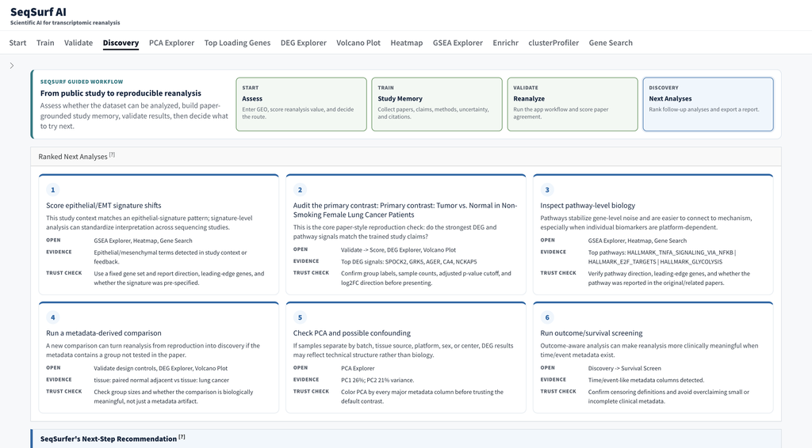

## 5 Current Demo Dataset: GSE19804

`GSE19804` is the main demo case because it supports the app’s core story: enter a public accession, classify the route, load prepared expression data, reanalyze, compare to paper claims, and show discovery recommendations.

| Demo Feature | Status |
| --- | --- |
| GEO accession input | Available |
| Study context loading | Available, with local cache for demo speed |
| Route classification | Available |
| Prepared expression dataset | Available locally |
| PCA and exploratory plots | Available |
| DEG result exploration | Available |
| Paper-claim comparison | Available |
| Reproducibility score | Available |
| Discovery recommendations | Available |
| Raw FASTQ/SRA processing | External handoff, not run inside the live demo |

## 6 What The Demo Proves

The demo is strongest if presented as a reproducibility and workflow-standardization prototype, not as a finished autonomous sequencing platform.

### 6.1 Demonstrated

- GEO accession to study triage.
- In-app route classification.
- Cached paper-aware study memory.
- Prepared expression reanalysis.
- PCA, DEG, volcano, heatmap, and pathway views.
- Paper-claim comparison.
- Reproducibility score.
- Discovery recommendations.
- Training-data export structure for future model development.

### 6.2 Not Yet Fully Automated

- End-to-end FASTQ download and alignment inside the app.
- Fully autonomous external workflow execution.
- True fine-tuned SeqSurf-specific ML model.
- Shared/global learning backend with consent controls and server infrastructure.
- Prospective clinical validation.

## 7 The Standardized Analysis Contract

SeqSurf AI is built around a simple idea: public dataset reuse should leave behind a structured record. Each dataset interaction should answer the same questions.

| Contract Element | Question |
| --- | --- |
| Dataset identity | What accession, organism, assay, and sample count are being analyzed? |
| Route | Can the app analyze it directly, import counts, or does it need external raw-data processing? |
| Evidence | What papers, methods, and claims define the expected result? |
| Design | Which group column, contrast, covariates, and filtering rules were used? |
| Reanalysis | What results did the standardized app workflow produce? |
| Agreement | Which claims were reproduced, different, or not testable? |
| Score | How strong is the post-analysis reproducibility signal? |
| Pitfalls | What metadata, batch, tissue, cell-type, or platform issues must be checked? |
| Next step | What analysis would be most useful now? |

This contract is the foundation for future learning. If many analyses are captured in a consistent structure, the system can eventually learn which dataset features predict useful reanalysis, which pitfalls matter most, and which analysis routes are likely to succeed.

## 8 Adaptive Learning Goal

The long-term product goal is a SeqSurf-specific smart model. The model would not replace scientific judgment. It would improve recommendations by learning from many structured dataset interactions.

The intended learning loop is:

1. A user analyzes a dataset.
2. SeqSurf records the route, claims, methods, analysis design, result agreement, score, pitfalls, and chosen next steps.
3. The user can export private local training examples.
4. With consent, privacy-preserving summaries can contribute to shared/global learning.
5. Future recommendations become more accurate for similar datasets, platforms, diseases, contrasts, and signatures.

Examples of future learned recommendations:

- “This GEO dataset is likely worth reanalysis because similar processed-matrix lung cancer datasets often reproduce core tumor-normal markers but reveal batch-sensitive immune signatures.”
- “This dataset should not be used for epithelial signature claims until tissue source and sample labels are reconciled.”
- “Use pathway-level analysis before individual-gene claims because related datasets showed unstable single-gene rankings.”

## 9 Evaluation Plan

For a healthcare AI paper or demo, evaluation should focus on workflow behavior and reproducibility structure before making clinical claims.

| Evaluation Area | Example Evidence |
| --- | --- |
| Workflow completion | Can a user move from GEO accession to report without manual code edits? |
| Route classification | Does the app correctly separate processed matrix, count matrix, raw/SRA handoff, and not-ready datasets? |
| Paper grounding | Does the study memory capture methods, claims, uncertainty, and citation evidence? |
| Reanalysis validity | Does the app generate PCA, differential expression views, pathway views, and report artifacts? |
| Claim agreement | Are paper claims compared against app results in a structured table? |
| Reproducibility scoring | Does the app produce a transparent score with rationale, not just a black-box number? |
| Pitfall surfacing | Does the app flag common issues such as phenotype ambiguity, batch effects, platform mismatch, and weak contrast definitions? |
| Learning readiness | Can interactions be exported as structured examples for a future SeqSurf-specific model? |

## 10 Suggested Demo Script

1. Open SeqSurf AI.
2. Enter `GSE19804`.
3. Show the Start page and explain the route classification.
4. Move to Train and show the study memory.
5. Move to Validate and show the design, report, paper agreement, and score.
6. Open PCA Explorer and show that the app creates standard exploratory views.
7. Move to Discovery and show next-analysis recommendations and pitfalls.
8. Close with the training-data export and adaptive-learning roadmap.

## 11 Plain-Language Pitch

SeqSurf AI is a reproducibility assistant for public transcriptomic data. It helps researchers go from a GEO accession to a paper-grounded reanalysis plan, then checks whether the app’s standardized analysis supports or differs from published findings. Its long-term purpose is to make public sequencing reuse more consistent, more transparent, and eventually smarter as the system learns from each dataset analyzed.